# am-lab-9

Pradeep Paladugula

3/15/2020

#Introduction To Linear Regression

# In this lab we’ll be looking at data from all 30 Major League

# Baseball teams and examining the linear relationship between runs scored in a season and

# a many of other player statistics.

# Our aim will be to summarize these relationships both graphically and numerically in order to find

# which variable, if any, helps us best predict a team’s runs scored in a season.

#The data

#Let’s load up the data for the 2011 season.

```r
download.file("http://www.openintro.org/stat/data/mlb11.RData", destfile = "mlb11.RData")

load("mlb11.RData")
```

#In addition to runs scored, there are seven traditionally used variables in the data set: at-bats, hits, #home runs, batting average, strikeouts, stolen bases, and wins. #There are also three newer variables: on-base percentage, slugging percentage, and on-base plus slugging. #For the first portion of the analysis we’ll consider the seven traditional variables. #At the end of the lab, you’ll work with the newer variables on your own.

# Exercise 1:

# What type of plot would you use to display the relationship between runs and one of the

# other numerical variables?

```r
plot(mlb11$at_bats, mlb11$runs)
abline(lm( mlb11$runs ~ mlb11$at_bats))
```

[output not shown]

# Plot this relationship using the variable at_bats as the predictor.

```r
m1 = (lm( mlb11$runs ~ mlb11$at_bats, data = mlb11))
summary(m1)
```

```
##
## Call:
## lm(formula = mlb11$runs ~ mlb11$at_bats, data = mlb11)
##
## Residuals:
##     Min      1Q  Median      3Q     Max
## -125.58  -47.05  -16.59   54.40  176.87
##
## Coefficients:
##                 Estimate Std. Error t value Pr(>|t|)
## (Intercept)   -2789.2429   853.6957  -3.267 0.002871 **
## mlb11$at_bats     0.6305     0.1545   4.080 0.000339 ***
## ---
## Signif. codes:  0 '***' 0.001 '**' 0.01 '*' 0.05 '.' 0.1 ' ' 1
##
## Residual standard error: 66.47 on 28 degrees of freedom
## Multiple R-squared:  0.3729, Adjusted R-squared:  0.3505
## F-statistic: 16.65 on 1 and 28 DF,  p-value: 0.0003388
```

# Does the relationship look linear? If you knew a team’s at_bats, would you be comfortable using a

# linear model to predict the number of runs?

```r
cor(mlb11$runs, mlb11$at_bats)
```

```
## [1] 0.610627
```

# Sum of squared residuals

# Think back to the way that we described the distribution of a single variable.

# Recall that we discussed characteristics such as center, spread, and shape.

# It’s also useful to be able to describe the relationship of two numerical variables,

# such as runs and at_bats above.

# Exercise 2:

# Looking at your plot from the previous exercise, describe the relationship between

# these two variables. Make sure to discuss the form, direction, and strength of the relationship

# as well as any unusual observations.

# Just as we used the mean and standard deviation to summarize a single variable, we can summarize

# the relationship between these two variables by finding the line that best follows

# their association. Use the following interactive function to select the line that you think

# does the best job of going through the cloud of points.

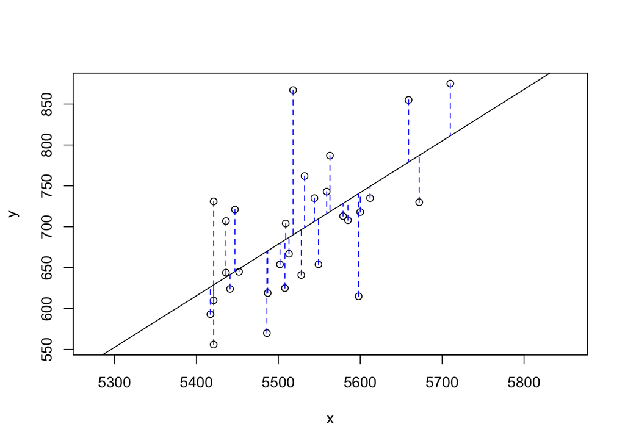

```
## Click two points to make a line.

## Call:
## lm(formula = y ~ x, data = pts)
##
## Coefficients:
## (Intercept)            x
##  -2789.2429       0.6305
##
## Sum of Squares:  123721.9
```

```r
plot_ss(x = mlb11$at_bats, y = mlb11$runs)
```

# After running this command, you’ll be prompted to click two points on the plot to define a line.

# Once you’ve done that, the line you specified will be shown in black and the residuals in blue.

# Note that there are 30 residuals, one for each of the 30 observations.

# Recall that the residuals are the difference between the observed values and the values

# predicted by the line:

# ei=yi-y^i

# The most common way to do linear regression is to select the line that minimizes the

# sum of squared residuals. To visualize the squared residuals, you can rerun the plot command

# and add the argument showSquares = TRUE.

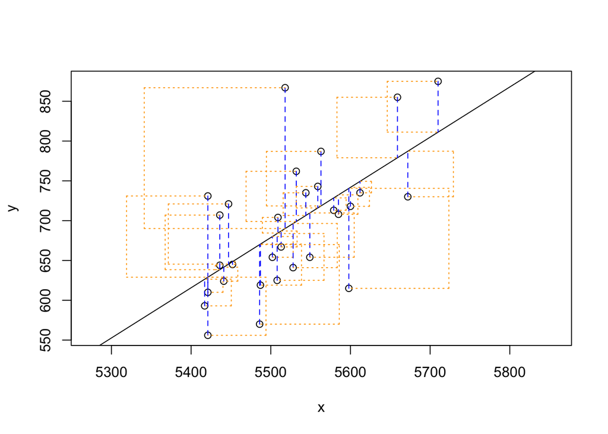

```
## Click two points to make a line.

## Call:
## lm(formula = y ~ x, data = pts)
##
## Coefficients:
## (Intercept)            x
##  -2789.2429       0.6305
##
## Sum of Squares:  123721.9
```

```r
plot_ss(x = mlb11$at_bats, y = mlb11$runs, showSquares = TRUE)
```

# Note that the output from the plot_ss function provides you with the slope and intercept of your

# line as well as the sum of squares.

#Exercise 3 #Using plot_ss, choose a line that does a good job of minimizing the sum of squares. #Run the function several times. What was the smallest sum of squares that you got? #How does it compare to your neighbors?

## The linear model Function lm()

#It is rather cumbersome to try to get the correct least squares line #i.e. the line that minimizes the sum of squared residuals, through trial and error. #Instead we can use the lm function in R to fit the linear model (a.k.a. regression line).

```r
m2 <- lm( runs ~ at_bats, data = mlb11)
```

# The first argument in the function lm is a formula that takes the form y ~ x.

# Here it can be read that we want to make a linear model of runs as a function of at_bats.

# The second argument specifies that R should look in the mlb11 data frame to find the runs

# and at_bats variables.

# The output of lm is an object that contains all of the information we need about the linear model that was just fit. We can access this information using the summary function.

```r
summary(m2)
```

```
##
## Call:
## lm(formula = runs ~ at_bats, data = mlb11)
##
## Residuals:
##     Min      1Q  Median      3Q     Max
## -125.58  -47.05  -16.59   54.40  176.87
##
## Coefficients:
##               Estimate Std. Error t value Pr(>|t|)
## (Intercept) -2789.2429   853.6957  -3.267 0.002871 **
## at_bats         0.6305     0.1545   4.080 0.000339 ***
## ---
## Signif. codes:  0 '***' 0.001 '**' 0.01 '*' 0.05 '.' 0.1 ' ' 1
##
## Residual standard error: 66.47 on 28 degrees of freedom
## Multiple R-squared:  0.3729, Adjusted R-squared:  0.3505
## F-statistic: 16.65 on 1 and 28 DF,  p-value: 0.0003388
```

# Let’s consider this output piece by piece.

# First, the formula used to describe the model is shown at the top.